# Bayesian Inference for Simple Linear Regression (Ch.14)

AG Schissler

03/30/2020

## How well does the first midterm score predict the second midterm score? (5 - 10 min)

```r
reg_data <- readRDS("data/exam_reg_data.rds")

### explore numerically
head(reg_data)
```

```
##   MidtermOne MidtermTwo
## 1         96         88
## 2         56         64
## 3         90         88
## 4         96         88
## 5         74         88
## 6         92         56
```

```r
summary(reg_data)
```

```
##    MidtermOne      MidtermTwo
##  Min.   :34.00   Min.   : 26
##  1st Qu.:80.00   1st Qu.: 84
##  Median :90.00   Median : 88
##  Mean   :85.72   Mean   : 84
##  3rd Qu.:96.00   3rd Qu.: 88
##  Max.   :98.00   Max.   :100
```

```r
cor(reg_data)
```

```
##            MidtermOne MidtermTwo
## MidtermOne  1.0000000  0.7722979
## MidtermTwo  0.7722979  1.0000000
```

```r
var(reg_data)
```

```
##            MidtermOne MidtermTwo
## MidtermOne   206.4926   163.8571
## MidtermTwo   163.8571   218.0000
```

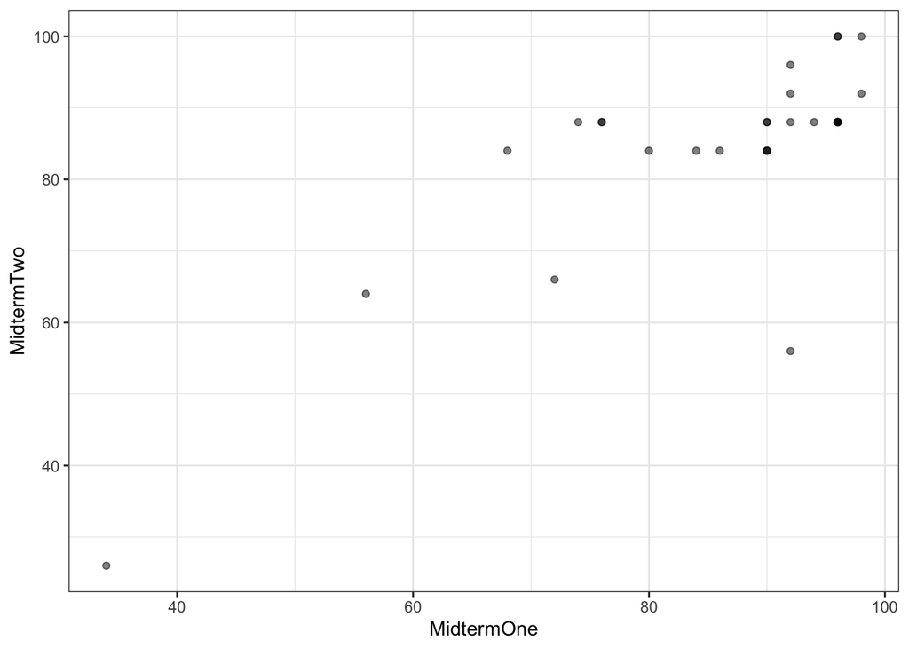

```r
## visualize relationship
## there are overlaying points so let's use translucency
## this is due to the discrete nature of scoring
p0 <- ggplot(data = reg_data, aes(x = MidtermOne, y = MidtermTwo) )
p0 + geom_point(alpha = 0.5)
```

Discuss…

## I. Compute the least squares (LS) estimates from these data (14.1; 15 - 20 min)

### Least squares regression

1. Discuss Figure 14.1.
2. Minimizing squared residuals: $SS_{res} = \sum_{i=1}^n \left[ y_i - (\alpha_0 + \beta x_i) \right]^2$ on p. 285.

LS Solution for $\beta$:  
$B = \frac{\overline{xy} - \overline{x}\overline{y}}{\overline{x^2} - \overline{x}^2}$.

LS Solution for $\alpha_0$:  
$A_0 = \overline{y} - B \overline{x}$.

The final LS solution is $y = A_0 + Bx$.

3. Discuss Example 14.1 and figure 14.2.

**Make sure to keep all significant digits** when calculating LS.

### Estimating the variance around the LS line

```r
compute_simple_ls <- function(x, y) {
    B <- ( mean(x*y) - mean(x) * mean(y) ) / ( mean(x^2) - mean(x)^2  )
    A0 <- mean(y) - B * mean(x)
    return( list(A0 = A0, B = B) )
}

estimate_var_simple_ls <- function(x, y) {
    ls_soln <- compute_simple_ls(x = x, y = y)
    fits <- ls_soln$A0 + ls_soln$B * x
    residuals <- y - fits
    return( ( 1 / (length(y) - 2) ) * sum( residuals^2 ) )
}
```

### Produce the LS solution for our exam data

```r
## Standardization is usually recommended, but to keep the scale clear
## for teaching purposes we fit to the original data

(my_ls_soln <- compute_simple_ls(x = reg_data$MidtermOne, y = reg_data$MidtermTwo))
```

```
## $A0
## [1] 15.97571
##
## $B
## [1] 0.7935255
```

```r
## compare to stats::lm()
lm(MidtermTwo ~ MidtermOne, data = reg_data)
```

```
##
## Call:
## lm(formula = MidtermTwo ~ MidtermOne, data = reg_data)
##
## Coefficients:
## (Intercept)   MidtermOne
##     15.9757       0.7935
```

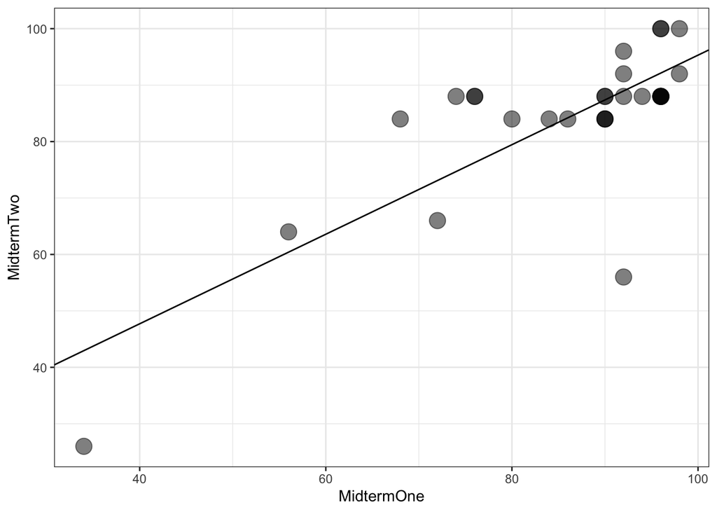

```r
p0 <- ggplot(data = reg_data, mapping =  aes(x = MidtermOne, y = MidtermTwo))
p1 <- p0 + geom_point(alpha = 0.5, size = 5) + geom_abline(intercept = my_ls_soln$A0, slope = my_ls_soln$B)
p1
```

```r
ols_fit <- lm(MidtermTwo ~ MidtermOne, data = reg_data)

summary(ols_fit)
```

```
##
## Call:
## lm(formula = MidtermTwo ~ MidtermOne, data = reg_data)
##
## Residuals:
##     Min      1Q  Median      3Q     Max
## -32.980  -4.154  -0.219   6.259  14.065
##
## Coefficients:
##             Estimate Std. Error t value Pr(>|t|)
## (Intercept)  15.9757    10.9134   1.464    0.155
## MidtermOne    0.7935     0.1256   6.317 9.22e-07 ***
## ---
## Signif. codes:  0 '***' 0.001 '**' 0.01 '*' 0.05 '.' 0.1 ' ' 1
##
## Residual standard error: 9.552 on 27 degrees of freedom
## Multiple R-squared:  0.5964, Adjusted R-squared:  0.5815
## F-statistic: 39.91 on 1 and 27 DF,  p-value: 9.215e-07
```

## II. Exponential growth model as a linear model after transformation (14.2; 5 - 10 min)

Often data do not display a linear trend, but one that reflects an increasing rate and variation as the predictor’s value increases.

In this case an exponential growth model will usually give a better fit:

$u = e^{\alpha_0 + \beta \times t}$. Then if we let $y = log(u)$, (here $log := log_e$)

$y = \alpha_0 + \beta \times t$.

Then you can find the LS solutions for the two parameters and back-transform to convert back to the original scale.

### Discuss Example 14.2 and Figure 14.3.

## III. Adding probablistic assumptions (14.3; 5 - 10 min)

There has been no probability or error modeling in the LS solution. It is called *distribution free* for this reason. So one can find the best fitting line with respect to the quadratic loss function, but there is no uncertainty quantification. Let’s add some probablisitc/statistical assumptions to meet this goal:

1. Mean assumption: The conditional mean of $y | x$ is an unknown linear function of $x$.

$\mu_{y|x} = \alpha_0 + \beta x$ or, equivalently, $\mu_{y|x} = \alpha_{\overline{x}} + \beta \left( x - \overline{x} \right)$.

2. Error assumption. Observation equals mean plus error, which is *normally* distributed with mean 0 and **known** variance $\sigma^2$ All errors have equal variance.
3. Independence assumption. The errors for all observations are independent of each other

See argument on p.291 and discuss Figure 14.5.

### How well do are data meet these assumptions?

## IV. Bayes Theorem for the regression model (14.4 part I; 15 - 20 min)

Bayes, theorem is always described as

$posterior \propto prior \times likelihood$. Let’s first discuss the joint likelihood.

Let’s walk through the derivation on p.293-294.

How does this relate to the frequentist approach of Maximum Likelihood Estimation (MLE)?

## V. Bayesian model development workflow

For real problems, I recommend the following Bayesian model development workflow:

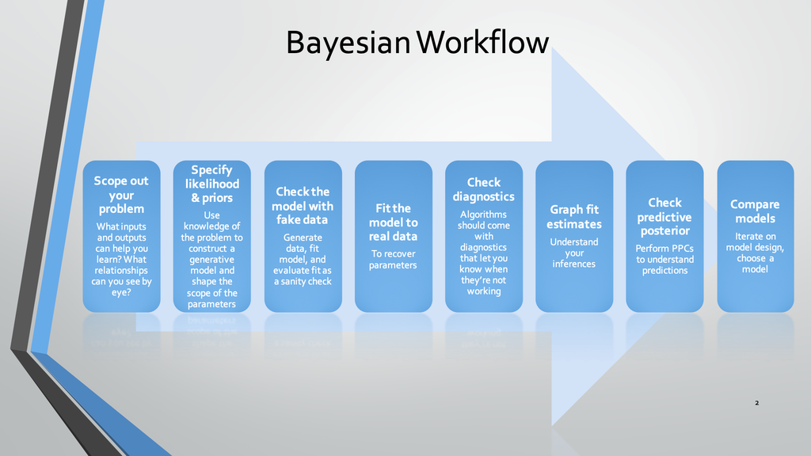

From Gabry et al. StanCon 2018

```r
knitr::include_graphics("figures/Bayesian_workflow_overview.png")
```

Learn more from the following preprint:

[Visualization in Bayesian workflow](https://arxiv.org/pdf/1709.01449.pdf)

## Closing (5 - 10 min)

Think-pair-share:

- Why do we bother with making probabilistic modeling assumptions instead of just giving the least squares solution?

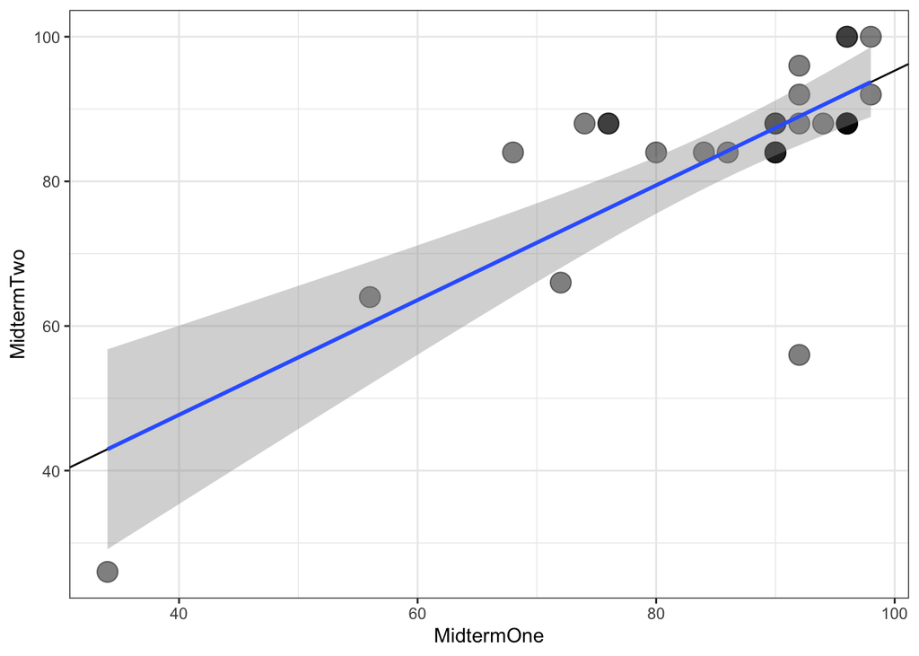

```r
p1+ geom_smooth(method = "lm")
```

- How will you adjust your project tasks based on the workflow?